# Brain Cancer Classification using MobileNet

## Satish Swarnkar

[figure not shown]

# **Importing Required Libraries**

### Explanation:

- `os`: Used for interacting with the operating system (e.g., file handling).
- `numpy`: Provides support for numerical operations, essential for image processing.
- `pandas`: Used for handling structured data.
- `seaborn & matplotlib.pyplot`: Used for visualization (accuracy/loss curves, confusion matrix, etc.).
- `PIL (Python Imaging Library)`: Handles image loading and processing.
- `tqdm`: Provides progress bars for loops.
- `shutil`: Handles file and directory operations.

```python
# Required Imports
import os
import numpy as np
import pandas as pd
import seaborn as sns
import matplotlib.pyplot as plt
from PIL import Image
from tqdm import tqdm
import shutil  # Add this import
```

# **TensorFlow/Keras Imports**

### Explanation:

- **TensorFlow & Keras**: The deep learning framework used for training the model.
- **Sequential API**: Used to build the deep learning model layer by layer.
- **CNN Layers:**
  - `Conv2D`: Convolutional layer for feature extraction.
  - `MaxPooling2D`: Reduces feature map size while retaining important features.
  - `Flatten`: Converts the 2D feature maps into a 1D vector.
  - `Dense`: Fully connected layer for classification.
  - `Dropout`: Reduces overfitting.
  - `Rescaling`: Normalizes input images.
- **MobileNet**: Pre-trained CNN model chosen for classification.

```python
# Core TensorFlow/Keras imports
import tensorflow as tf
import keras
from keras import Sequential
from keras.layers import Dense, Conv2D, MaxPooling2D, Flatten, Dropout, Rescaling
#from keras.applications.vgg16 import VGG16
from keras.applications.mobilenet import MobileNet  # Replace VGG16 import

from keras.optimizers import Adam
from keras.utils import image_dataset_from_directory
```

# **Optimizers & Callbacks**

### Explanation:

```python
from keras.optimizers import Adam          # Instead of tensorflow.keras.optimizers
from keras.callbacks import EarlyStopping, ReduceLROnPlateau  # Instead of tensorflow.keras.callbacks
```

# **Importing Evaluation Metrics**

### Explanation:

- **Metrics for evaluating model performance:**
  - `accuracy_score`: Measures classification accuracy.
  - `precision_score, recall_score, f1_score`: Metrics for handling class imbalance.
  - `confusion_matrix`: Shows the number of correct vs. incorrect predictions.
  - `roc_curve & auc`: Evaluates classification ability.
  - `precision_recall_curve & average_precision_score`: Analyzes precision-recall trade-offs.

```python
# Sklearn imports
from sklearn.metrics import (
    accuracy_score,
    precision_score,
    recall_score,
    f1_score,
    confusion_matrix,
    classification_report,
    roc_curve,
    auc,
    precision_recall_curve,
    average_precision_score
)
```

# **Suppressing TensorFlow Warnings**

### Explanation:

- TensorFlow generates many logs during execution. This suppresses unnecessary logs, keeping the output cleaner.

```python
import logging
os.environ['TF_CPP_MIN_LOG_LEVEL'] = '2'  # Suppress TF logging
logging.getLogger('tensorflow').setLevel(logging.ERROR)  # Only show errors
```

# **Setting Random Seeds**

### Explanation:

- Ensures **reproducibility** by setting fixed random seeds for NumPy and TensorFlow.
- Without this, results might slightly change across runs.

```python
# Set random seeds
np.random.seed(42)
tf.random.set_seed(42)
```

# **Function to Get Class Distribution**

### Explanation:

- Scans the dataset directory and **counts how many images belong to each class**.
- Returns the **top N most frequent classes**.
- Sorting ensures that the most frequent cancer types are included in training.

```python
def get_class_distribution(data_dir, n_classes=3):
    """Get top n classes and their image counts"""
    class_counts = {}
    for class_name in os.listdir(data_dir):
        class_path = os.path.join(data_dir, class_name)
        if os.path.isdir(class_path):
            class_counts[class_name] = len(os.listdir(class_path))

    top_classes = sorted(class_counts.items(), key=lambda x: x[1], reverse=True)[:n_classes]

    print("\nFull Class Distribution:")
    print("-" * 40)
    for class_name, count in top_classes:
        print(f"{class_name} ({translate[class_name]}): {count} images")

    return [cls[0] for cls in top_classes]
```

# **Creating Data Generators**

### Explanation:

- **Prepares dataset for training:**
  - Selects only the **top classes**.
  - Uses `image_dataset_from_directory()` to load images.
  - **Splits into training (80%) and validation (20%)**.
  - **Normalizes images (`Rescaling(1./255)`)**.
  - Uses **caching & prefetching** for optimized training.

```python
def create_data_generators(data_dir='BrainImages', img_size=(224, 224), batch_size=32, n_images_per_class=0, number_of_classes=3):
    import shutil
    print("Creating data generators...")

    # Get top classes
    top_classes = get_class_distribution(data_dir, number_of_classes)
    print(f"\nUsing classes: {[f'{cls} ({translate[cls]})' for cls in top_classes]}")

    # Create a temporary directory for the selected classes
    #subset_dir = 'selected_classes'

    # Extract dataset type from data_dir
    dataset_type = os.path.basename(data_dir)  # Gets the last part of the path

    # Create a unique temporary directory name
    subset_dir = f'selected_classes_{dataset_type}'

    print(f"Creating temporary directory: {subset_dir}")

    if os.path.exists(subset_dir):
        shutil.rmtree(subset_dir)
    os.makedirs(subset_dir)

    # Copy only the top classes
    for class_name in top_classes:
        src_path = os.path.join(data_dir, class_name)
        dst_path = os.path.join(subset_dir, class_name)

        os.makedirs(dst_path)
        images = sorted(os.listdir(src_path))

        if n_images_per_class > 0:
            images = images[:n_images_per_class]

        for img in images:
            src_file = os.path.join(src_path, img)
            dst_file = os.path.join(dst_path, img)
            shutil.copy2(src_file, dst_file)

    print("\nLoading training data...")
    train_ds = image_dataset_from_directory(
        subset_dir,
        validation_split=0.2,
        subset="training",
        seed=123,
        image_size=img_size,
        batch_size=batch_size
    )

    print("\nLoading validation data...")
    val_ds = image_dataset_from_directory(
        subset_dir,
        validation_split=0.2,
        subset="validation",
        seed=123,
        image_size=img_size,
        batch_size=batch_size
    )

    # Save class names before normalization
    class_names = train_ds.class_names

    # Add caching before normalization
    train_ds = train_ds.cache()
    val_ds = val_ds.cache()

    # Add normalization
    normalization_layer = Rescaling(1./255)

    # Add performance optimizations
    train_ds = train_ds.map(lambda x, y: (normalization_layer(x), y))
    train_ds = train_ds.prefetch(tf.data.AUTOTUNE)

    val_ds = val_ds.map(lambda x, y: (normalization_layer(x), y))
    val_ds = val_ds.prefetch(tf.data.AUTOTUNE)

    return train_ds, val_ds, subset_dir, class_names
```

# **Creating MobileNet-based CNN Model**

### Explanation:

- Uses **MobileNet as a feature extractor** (pre-trained on ImageNet).
- The **base model’s layers are frozen** to retain learned features.
- Additional **fully connected (Dense) layers** are added:
  - **512 & 256 neurons** with ReLU activation.
  - **Dropout layers (0.5 & 0.3) to prevent overfitting**.
  - **Final Softmax layer** for classification.

```python
def create_model(input_shape, num_classes):
    """Create and return the CNN model using MobileNet"""
    base_model = MobileNet(  # Changed from VGG16 to MobileNet
        weights='imagenet',
        include_top=False,
        input_shape=input_shape
    )

    base_model.trainable = False

    model = Sequential([
        base_model,
        Flatten(),
        Dense(512, activation='relu'),
        Dropout(0.5),
        Dense(256, activation='relu'),
        Dropout(0.3),
        Dense(num_classes, activation='softmax')
    ])
    model.build((None,) + input_shape)

    return model
```

# **Compiling the Model**

### Explanation:

- Calls `create_model()` and **prints model summary**.
- Compiles model using:
  - **Adam optimizer (learning rate = 0.0005)**.
  - **Sparse categorical crossentropy** (since labels are integers).
  - **Accuracy as the main evaluation metric**.

```python
def setup_model(img_size, num_classes):
    """Creates and compiles the model with optimized settings"""
    # Create model as before
    model = create_model(
        input_shape=(img_size[0], img_size[1], 3),
        num_classes=num_classes
    )
    print("\nModel Summary:")
    model.summary()

    # Compile with optimized settings
    model.compile(
        optimizer=Adam(
            learning_rate=0.0005,  # Higher initial learning rate since we're using reduction
            beta_1=0.9,
            beta_2=0.999,
            epsilon=1e-07
        ),
        loss='sparse_categorical_crossentropy',
        metrics=['accuracy'],
        # jit_compile=True  # Disabled for MobileNet. This can be enabled for VGG16. Enable XLA compilation for faster training
    )

    return model
```

# **Setting Up Training Callbacks**

### Explanation:

- **ReduceLROnPlateau**: Decreases learning rate if validation loss stops improving.
- **EarlyStopping**: Stops training if validation loss doesn’t improve for 4 epochs.
- These help **prevent overfitting** and improve model convergence.

```python
def setup_training_callbacks():
    """Sets up training callbacks with both early stopping and learning rate reduction"""
    return [
        # Learning rate reduction callback
        keras.callbacks.ReduceLROnPlateau(
            monitor='val_loss',
            factor=0.5,      # Reduce LR by half
            patience=2,      # Wait 2 epochs before reducing
            min_lr=1e-6,     # Minimum LR threshold
            mode='min',
            verbose=1        # Print reduction messages
        ),
        # Early stopping with added parameters
        keras.callbacks.EarlyStopping(
            monitor='val_loss',
            patience=4,      # Increased to give LR reduction a chance to work
            restore_best_weights=True,
            mode='min',
            verbose=1
        )
    ]
```

# **Training the Model**

### Explanation:

- Calls `model.fit()` to start training.
- Uses callbacks (`EarlyStopping`, `ReduceLROnPlateau`).
- Returns **training history** (accuracy/loss per epoch).

```python
def train_model_core(model, train_ds, val_ds, epochs, callbacks):
    """Core training function"""
    print("\nTraining model...")
    history = model.fit(
        train_ds,
        validation_data=val_ds,
        epochs=epochs,
        callbacks=callbacks
    )
    return history
```

# **Function to Train the Model**

### Explanation:

- Handles **the entire model training process**, including:
  - **Dataset loading** using `create_data_generators()`.
  - **Model creation and compilation** using `setup_model()`.
  - **Callback setup** to prevent overfitting.
  - **Training execution** using `model.fit()`.
- Returns the **trained model, training history, and dataset references**.

```python
def train_model(data_dir='BrainImages', img_size=(224, 224), batch_size=32,
                epochs=20, n_images_per_class=0, number_of_classes=3):
    """Main orchestration function"""
    # 1. Setup data
    train_ds, val_ds, subset_dir, class_names = create_data_generators(
        data_dir=data_dir,
        img_size=img_size,
        batch_size=batch_size,
        n_images_per_class=n_images_per_class,
        number_of_classes=number_of_classes
    )

    # 2. Setup model
    model = setup_model(img_size, number_of_classes)

    # 3. Setup callbacks
    callbacks = setup_training_callbacks()

    # 4. Train model
    history = train_model_core(model, train_ds, val_ds, epochs, callbacks)

    return model, history, val_ds, class_names, subset_dir, train_ds
```

# **Function to Plot Training History**

### Explanation:

- Plots **training accuracy vs. validation accuracy** and **training loss vs. validation loss**.
- **Accuracy**: Measures how well the model predicts the correct class.
  - In a well-trained model, accuracy should **increase** over epochs.
  - If training accuracy increases but validation accuracy stagnates or drops, the model may be **overfitting**.
- **Loss**: Measures the error in model predictions.
  - Loss should **decrease** over epochs for a well-performing model.
  - If validation loss increases while training loss decreases, the model is **memorizing training data** instead of generalizing.
- Helps analyze model **performance trends** over time.

```python
def plot_training_history(history):
    """Plot training history"""
    plt.figure(figsize=(12, 4))

    plt.subplot(1, 2, 1)
    plt.plot(history.history['accuracy'])
    plt.plot(history.history['val_accuracy'])
    plt.title('Model Accuracy')
    plt.xlabel('Epoch')
    plt.ylabel('Accuracy')
    plt.legend(['Train', 'Validation'])

    plt.subplot(1, 2, 2)
    plt.plot(history.history['loss'])
    plt.plot(history.history['val_loss'])
    plt.title('Model Loss')
    plt.xlabel('Epoch')
    plt.ylabel('Loss')
    plt.legend(['Train', 'Validation'])

    plt.tight_layout()
    plt.show()
```

# **Printing Dataset Summary**

### Explanation:

- Prints **dataset statistics** including:
  - Number of **images per class**.
  - **Total number of images** in training and validation datasets.
  - **Batch size and number of training steps per epoch**.
- Helps verify dataset **distribution and batch processing** before training.

```python
def print_dataset_summary(train_ds, val_ds, n_images_per_class, number_of_classes, batch_size):
    """Print detailed dataset statistics"""
    total_images = n_images_per_class * number_of_classes
    train_steps = len(train_ds)
    val_steps = len(val_ds)

    print("\nDataset Summary:")
    print(f"Images per class: {n_images_per_class}")
    print(f"Number of classes: {number_of_classes}")
    print(f"Total images: {total_images}")
    print(f"Training images: {len(train_ds) * batch_size}")
    print(f"Validation images: {len(val_ds) * batch_size}")
    print(f"Batch size: {batch_size}")
    print(f"Training steps per epoch: {train_steps}")
    print(f"Validation steps per epoch: {val_steps}")
```

# **Evaluating the Model**

### Explanation:

- **Computes model evaluation metrics**:
  - **Accuracy, Precision, Recall, F1 Score**
  - **Classification Report**
- **Generates and plots evaluation graphs**:
  - **Confusion Matrix**
  - **ROC Curves**
  - **Precision-Recall Curves**
- Helps analyze the model’s classification performance across different cancer types.

```python
def evaluate_model(model, val_ds, class_names):
    """Comprehensive model evaluation with ROC and PR curves"""
    # Get predictions
    all_predictions = []
    all_labels = []

    for images, labels in val_ds:
        predictions = model.predict(images, verbose=0)
        all_predictions.extend(predictions)
        all_labels.extend(labels.numpy())

    all_predictions = np.array(all_predictions)
    all_labels = np.array(all_labels)

    # Convert predictions to classes
    pred_classes = np.argmax(all_predictions, axis=1)

    # Calculate and print metrics
    print("\nModel Evaluation Metrics:")
    print("------------------------")
    accuracy = accuracy_score(all_labels, pred_classes)
    precision = precision_score(all_labels, pred_classes, average='weighted')
    recall = recall_score(all_labels, pred_classes, average='weighted')
    f1 = f1_score(all_labels, pred_classes, average='weighted')

    print(f"Accuracy: {accuracy:.4f}")
    print(f"Precision: {precision:.4f}")
    print(f"Recall: {recall:.4f}")
    print(f"F1 Score: {f1:.4f}")

    # Print classification report
    print("\nClassification Report:")
    print("---------------------")
    print(classification_report(all_labels, pred_classes, target_names=class_names))

    # Plot confusion matrix
    plt.figure(figsize=(10, 8))
    cm = confusion_matrix(all_labels, pred_classes)
    sns.heatmap(cm, annot=True, fmt='d', cmap='Blues',
                xticklabels=class_names, yticklabels=class_names)
    plt.title('Confusion Matrix')
    plt.xlabel('Predicted')
    plt.ylabel('True')
    plt.show()

    # Plot ROC curves
    plt.figure(figsize=(10, 8))
    for i, class_name in enumerate(class_names):
        # Convert to one-vs-rest binary classification
        y_true = (all_labels == i).astype(int)
        y_score = all_predictions[:, i]

        fpr, tpr, _ = roc_curve(y_true, y_score)
        roc_auc = auc(fpr, tpr)

        plt.plot(fpr, tpr, label=f'{class_name} (AUC = {roc_auc:.2f})')

    plt.plot([0, 1], [0, 1], 'k--')
    plt.xlabel('False Positive Rate')
    plt.ylabel('True Positive Rate')
    plt.title('ROC Curves')
    plt.legend()
    plt.show()

    # Plot Precision-Recall curves
    plt.figure(figsize=(10, 8))
    for i, class_name in enumerate(class_names):
        y_true = (all_labels == i).astype(int)
        y_score = all_predictions[:, i]

        precision_curve, recall_curve, _ = precision_recall_curve(y_true, y_score)
        avg_precision = average_precision_score(y_true, y_score)

        plt.plot(recall_curve, precision_curve,
                label=f'{class_name} (AP = {avg_precision:.2f})')

    plt.xlabel('Recall')
    plt.ylabel('Precision')
    plt.title('Precision-Recall Curves')
    plt.legend()
    plt.show()
```

# **Function to Show Sample Images**

### Explanation:

- Displays a **grid of sample images** from each class in the dataset.
- Helps **visually verify** that the dataset is correctly loaded before training.
- **Rescales images back to their original pixel range** before displaying.
- Uses **Matplotlib** to generate subplots with multiple images.

```python
def show_sample_images(dataset, samples_per_class=3, class_names=None):
    """
    Display a grid of sample images from each class in the dataset.

    Args:
        dataset: TensorFlow dataset
        samples_per_class: Number of samples to show per class
        class_names: List of class names (optional)
    """
    import matplotlib.pyplot as plt

    # Get sample images for each class
    samples = {}
    for images, labels in dataset:
        for image, label in zip(images, labels):
            label = int(label)
            if label not in samples:
                samples[label] = []
            if len(samples[label]) < samples_per_class:
                # Rescale image back to [0,255] range
                image = image * 255.0
                samples[label].append(image)
        if all(len(imgs) >= samples_per_class for imgs in samples.values()):
            break

    # Set up the plot grid
    n_classes = len(samples)
    fig, axes = plt.subplots(n_classes, samples_per_class,
                            figsize=(samples_per_class * 3, n_classes * 3))

    # Plot each sample
    for i, (label, images) in enumerate(samples.items()):
        for j, image in enumerate(images):
            ax = axes[i, j] if n_classes > 1 else axes[j]
            ax.imshow(image.numpy().astype("uint8"))
            ax.axis('off')
            if j == 0:
                title = f"Class {label}"
                if class_names and label < len(class_names):
                    title = class_names[label]
                ax.set_title(title, pad=10)

    plt.tight_layout()
    plt.show()
```

# **Defining Paths and Hyperparameters**

### Explanation:

- Defines **dataset and model storage paths**.
- Sets **key hyperparameters** for model training:
  - **Image size**: `224x224`
  - **Batch size**: `128`
  - **Epochs**: `32`
  - **Classes**: `3` (Glioma, Meningioma, Pituitary Tumor)
- Limits dataset to `5000` images per class (modifiable).

```python
data_dir = 'Cancer/Brain Cancer'
model_store_dir = 'brain_cancer_vgg16_classification_model.keras'

number_of_classes=3

samples_per_class=3 # Just show a few images as samples after training.

# Set number of images per class (0 for all images)

n_images = 5000  # Number of Images per Class, Set to 0 for all images

img_size = (224, 224)
batch_size = 128
epochs = 32
```

# **Class Name Translation Dictionary**

### Explanation:

- Maps **folder names** in the dataset to **human-readable class labels**.
- Used for **displaying correct class names** in reports and visualizations.

```python
# Translation dictionary
translate = {
    # folder_name to New_Label
    "brain_glioma": "Glioma",
    "brain_menin": "Meningioma",
    "brain_tumor": "Pituitary Tumor"
}
```

# **Main Execution Block**

### Explanation:

- Runs the **entire model training pipeline**.
- Passes **hyperparameters** and dataset configurations.
- Calls `train_model()` which:
  - **Loads the dataset**
  - **Builds the MobileNet-based model**
  - **Trains the model with callbacks**
  - **Returns trained model and history**

```python
# Main execution
params = {
    'data_dir': data_dir,
    'img_size': img_size,
    'batch_size': batch_size,
    'epochs': epochs,
    'number_of_classes': number_of_classes,
    'n_images_per_class': n_images
}

model, history, val_ds, class_names, subset_dir, train_ds = train_model(**params)
```

```
Creating data generators...

Full Class Distribution:
----------------------------------------
brain_menin (Meningioma): 5000 images
brain_tumor (Pituitary Tumor): 5000 images
brain_glioma (Glioma): 5000 images

Using classes: ['brain_menin (Meningioma)', 'brain_tumor (Pituitary Tumor)', 'brain_glioma (Glioma)']
Creating temporary directory: selected_classes_Brain Cancer

Loading training data...
Found 15000 files belonging to 3 classes.
Using 12000 files for training.

Loading validation data...
Found 15000 files belonging to 3 classes.
Using 3000 files for validation.

Model Summary:
```

```
Model: "sequential"
```

```
┏━━━━━━━━━━━━━━━━━━━━━━━━━━━━━━━━━┳━━━━━━━━━━━━━━━━━━━━━━━━┳━━━━━━━━━━━━━━━┓
┃ Layer (type)                    ┃ Output Shape           ┃       Param # ┃
┡━━━━━━━━━━━━━━━━━━━━━━━━━━━━━━━━━╇━━━━━━━━━━━━━━━━━━━━━━━━╇━━━━━━━━━━━━━━━┩
│ mobilenet_1.00_224 (Functional) │ (None, 7, 7, 1024)     │     3,228,864 │
├─────────────────────────────────┼────────────────────────┼───────────────┤
│ flatten (Flatten)               │ (None, 50176)          │             0 │
├─────────────────────────────────┼────────────────────────┼───────────────┤
│ dense (Dense)                   │ (None, 512)            │    25,690,624 │
├─────────────────────────────────┼────────────────────────┼───────────────┤
│ dropout (Dropout)               │ (None, 512)            │             0 │
├─────────────────────────────────┼────────────────────────┼───────────────┤
│ dense_1 (Dense)                 │ (None, 256)            │       131,328 │
├─────────────────────────────────┼────────────────────────┼───────────────┤
│ dropout_1 (Dropout)             │ (None, 256)            │             0 │
├─────────────────────────────────┼────────────────────────┼───────────────┤
│ dense_2 (Dense)                 │ (None, 3)              │           771 │
└─────────────────────────────────┴────────────────────────┴───────────────┘
```

```
 Total params: 29,051,587 (110.82 MB)
```

```
 Trainable params: 25,822,723 (98.51 MB)
```

```
 Non-trainable params: 3,228,864 (12.32 MB)
```

```
Training model...
94/94 ━━━━━━━━━━━━━━━━━━━━ 29s 264ms/step - accuracy: 0.6378 - loss: 27.5006 - val_accuracy: 0.9457 - val_loss: 4.9587 - learning_rate: 5.0000e-04
94/94 ━━━━━━━━━━━━━━━━━━━━ 26s 273ms/step - accuracy: 0.8718 - loss: 14.5395 - val_accuracy: 0.9543 - val_loss: 3.9190 - learning_rate: 5.0000e-04
94/94 ━━━━━━━━━━━━━━━━━━━━ 28s 275ms/step - accuracy: 0.9171 - loss: 8.9124 - val_accuracy: 0.9653 - val_loss: 3.4346 - learning_rate: 5.0000e-04
94/94 ━━━━━━━━━━━━━━━━━━━━ 26s 269ms/step - accuracy: 0.9418 - loss: 6.5256 - val_accuracy: 0.9740 - val_loss: 2.3544 - learning_rate: 5.0000e-04
94/94 ━━━━━━━━━━━━━━━━━━━━ 27s 277ms/step - accuracy: 0.9603 - loss: 3.6618 - val_accuracy: 0.9763 - val_loss: 2.4552 - learning_rate: 5.0000e-04
94/94 ━━━━━━━━━━━━━━━━━━━━ 24s 245ms/step - accuracy: 0.9703 - loss: 2.8564 - val_accuracy: 0.9773 - val_loss: 2.3072 - learning_rate: 5.0000e-04
94/94 ━━━━━━━━━━━━━━━━━━━━ 25s 259ms/step - accuracy: 0.9812 - loss: 1.6915 - val_accuracy: 0.9810 - val_loss: 1.5915 - learning_rate: 5.0000e-04
94/94 ━━━━━━━━━━━━━━━━━━━━ 24s 244ms/step - accuracy: 0.9810 - loss: 1.5997 - val_accuracy: 0.9737 - val_loss: 3.1693 - learning_rate: 5.0000e-04
94/94 ━━━━━━━━━━━━━━━━━━━━ 24s 251ms/step - accuracy: 0.9837 - loss: 1.3857 - val_accuracy: 0.9837 - val_loss: 1.2717 - learning_rate: 5.0000e-04
94/94 ━━━━━━━━━━━━━━━━━━━━ 25s 262ms/step - accuracy: 0.9904 - loss: 0.9064 - val_accuracy: 0.9803 - val_loss: 2.2370 - learning_rate: 5.0000e-04
94/94 ━━━━━━━━━━━━━━━━━━━━ 0s 188ms/step - accuracy: 0.9894 - loss: 0.9885
Epoch 11: ReduceLROnPlateau reducing learning rate to 0.0002500000118743628.
94/94 ━━━━━━━━━━━━━━━━━━━━ 22s 233ms/step - accuracy: 0.9894 - loss: 0.9881 - val_accuracy: 0.9857 - val_loss: 1.4556 - learning_rate: 5.0000e-04
94/94 ━━━━━━━━━━━━━━━━━━━━ 26s 269ms/step - accuracy: 0.9921 - loss: 0.7452 - val_accuracy: 0.9847 - val_loss: 1.6326 - learning_rate: 2.5000e-04
94/94 ━━━━━━━━━━━━━━━━━━━━ 24s 240ms/step - accuracy: 0.9949 - loss: 0.3539 - val_accuracy: 0.9887 - val_loss: 1.0427 - learning_rate: 2.5000e-04
94/94 ━━━━━━━━━━━━━━━━━━━━ 22s 235ms/step - accuracy: 0.9954 - loss: 0.3011 - val_accuracy: 0.9880 - val_loss: 1.1590 - learning_rate: 2.5000e-04
94/94 ━━━━━━━━━━━━━━━━━━━━ 0s 199ms/step - accuracy: 0.9960 - loss: 0.3543
Epoch 15: ReduceLROnPlateau reducing learning rate to 0.0001250000059371814.
94/94 ━━━━━━━━━━━━━━━━━━━━ 24s 246ms/step - accuracy: 0.9960 - loss: 0.3531 - val_accuracy: 0.9830 - val_loss: 1.8398 - learning_rate: 2.5000e-04
94/94 ━━━━━━━━━━━━━━━━━━━━ 26s 270ms/step - accuracy: 0.9946 - loss: 0.4405 - val_accuracy: 0.9873 - val_loss: 1.1392 - learning_rate: 1.2500e-04
94/94 ━━━━━━━━━━━━━━━━━━━━ 24s 243ms/step - accuracy: 0.9960 - loss: 0.2586 - val_accuracy: 0.9877 - val_loss: 0.9442 - learning_rate: 1.2500e-04
94/94 ━━━━━━━━━━━━━━━━━━━━ 23s 242ms/step - accuracy: 0.9962 - loss: 0.2327 - val_accuracy: 0.9880 - val_loss: 1.0209 - learning_rate: 1.2500e-04
94/94 ━━━━━━━━━━━━━━━━━━━━ 0s 201ms/step - accuracy: 0.9960 - loss: 0.2400
Epoch 19: ReduceLROnPlateau reducing learning rate to 6.25000029685907e-05.
94/94 ━━━━━━━━━━━━━━━━━━━━ 24s 249ms/step - accuracy: 0.9960 - loss: 0.2404 - val_accuracy: 0.9887 - val_loss: 1.0392 - learning_rate: 1.2500e-04
94/94 ━━━━━━━━━━━━━━━━━━━━ 23s 240ms/step - accuracy: 0.9969 - loss: 0.1838 - val_accuracy: 0.9873 - val_loss: 1.0430 - learning_rate: 6.2500e-05
94/94 ━━━━━━━━━━━━━━━━━━━━ 0s 189ms/step - accuracy: 0.9981 - loss: 0.0761
Epoch 21: ReduceLROnPlateau reducing learning rate to 3.125000148429535e-05.
94/94 ━━━━━━━━━━━━━━━━━━━━ 22s 235ms/step - accuracy: 0.9981 - loss: 0.0763 - val_accuracy: 0.9883 - val_loss: 1.0626 - learning_rate: 6.2500e-05
Epoch 21: early stopping
Restoring model weights from the end of the best epoch: 17.
```

```python
translated_class_names = [translate[class_name] for class_name in class_names]
```

# **Function to Plot Training History**

### Explanation:

- Plots **training accuracy vs. validation accuracy** and **training loss vs. validation loss**.
- **Accuracy**: Measures how well the model predicts the correct class.
  - In a well-trained model, accuracy should **increase** over epochs.
  - If training accuracy increases but validation accuracy stagnates or drops, the model may be **overfitting**.
- **Loss**: Measures the error in model predictions.
  - Loss should **decrease** over epochs for a well-performing model.
  - If validation loss increases while training loss decreases, the model is **memorizing training data** instead of generalizing.
- Helps analyze model **performance trends** over time.

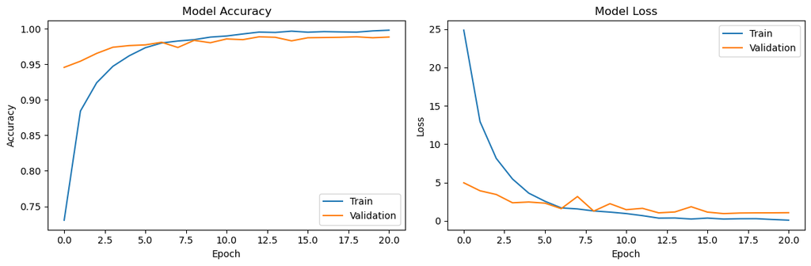

```python
# Plot training history
plot_training_history(history)
```

# **Displaying Sample Images from the Validation Dataset**

### Explanation:

- Displays **a selection of images from the validation dataset**.
- Helps verify that **image preprocessing is correctly applied**.
- Ensures that the **dataset includes well-distributed samples** for each class.
- Uses `translated_class_names` to ensure correct labeling of each displayed image.
- A useful step before evaluating model predictions.

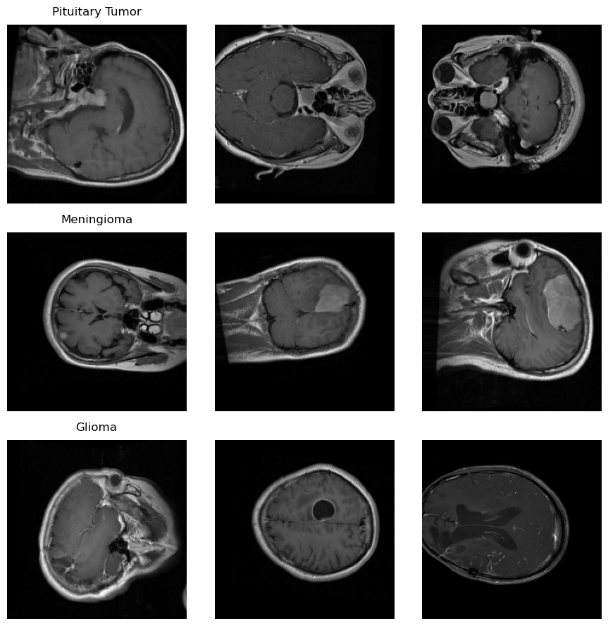

```python
# After training, show sample validation images
show_sample_images(val_ds, samples_per_class=3, class_names=translated_class_names)
```

# **Printing Dataset Summary**

### Explanation:

- Prints **dataset statistics** including:
  - Number of **images per class**.
  - **Total number of images** in training and validation datasets.
  - **Batch size and number of training steps per epoch**.
- Helps verify dataset **distribution and batch processing** before training.

```python
# After training
print_dataset_summary(train_ds, val_ds, n_images, number_of_classes, batch_size)
```

```
Dataset Summary:
Images per class: 5000
Number of classes: 3
Total images: 15000
Training images: 12032
Validation images: 3072
Batch size: 128
Training steps per epoch: 94
Validation steps per epoch: 24
```

# **Evaluating the Model**

### Explanation:

- Computes **performance metrics**:
  - **Accuracy, Precision, Recall, F1 Score**.
  - **Confusion Matrix** to analyze misclassifications.
  - **ROC and Precision-Recall curves** for multi-class classification.
- Helps assess how well the model performs on **unseen validation data**.

# **Understanding Evaluation Metrics**

### **Accuracy**

- Measures the proportion of correctly classified instances.
- Formula: `Accuracy = (TP + TN) / (TP + TN + FP + FN)`
- Higher accuracy indicates better model performance but may not be reliable for imbalanced datasets.

### **Precision**

- Measures how many of the predicted positive cases are actually positive.
- Formula: `Precision = TP / (TP + FP)`
- High precision means fewer **false positives**.

### **Recall (Sensitivity)**

- Measures how many actual positive cases were correctly identified.
- Formula: `Recall = TP / (TP + FN)`
- High recall means fewer **false negatives**.

### **F1 Score**

- The harmonic mean of precision and recall.
- Formula: `F1 Score = 2 * (Precision * Recall) / (Precision + Recall)`
- Used when there is an imbalance between precision and recall.

# **Confusion Matrix**

### Explanation:

- A **table that summarizes the model's performance** by comparing predicted vs. actual values.
- Structure:
  - **True Positives (TP)**: Correctly predicted positive cases.
  - **True Negatives (TN)**: Correctly predicted negative cases.
  - **False Positives (FP)**: Incorrectly predicted positives.
  - **False Negatives (FN)**: Incorrectly predicted negatives.
- Helps diagnose specific **classification errors** (e.g., false positives vs. false negatives).

# **ROC and Precision-Recall Curves for Multi-Class Classification**

### **ROC (Receiver Operating Characteristic) Curve**

- Plots **True Positive Rate (TPR) vs. False Positive Rate (FPR)**.
- AUC (Area Under Curve) measures classification performance.
- Higher AUC values indicate better classification ability.

### **Precision-Recall Curve**

- Plots **Precision vs. Recall** for different probability thresholds.
- Useful for evaluating models on imbalanced datasets.
- High precision-recall trade-off indicates **good model generalization**.

```
Model Evaluation Metrics:
------------------------
Accuracy: 0.9877
Precision: 0.9877
Recall: 0.9877
F1 Score: 0.9877

Classification Report:
---------------------
                 precision    recall  f1-score   support

         Glioma       0.99      0.99      0.99      1017
     Meningioma       0.98      0.98      0.98       987
Pituitary Tumor       0.99      0.99      0.99       996

       accuracy                           0.99      3000
      macro avg       0.99      0.99      0.99      3000
   weighted avg       0.99      0.99      0.99      3000
```

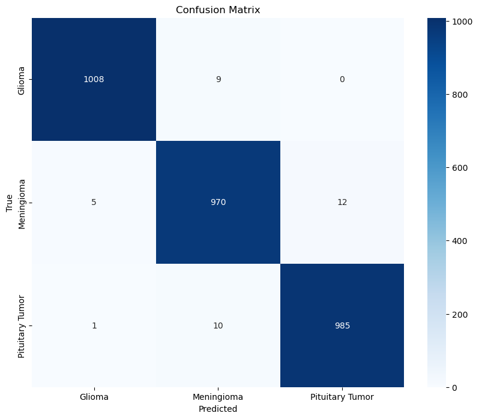

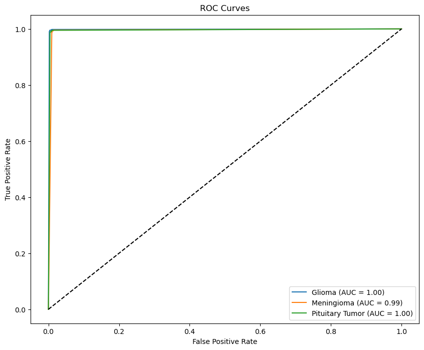

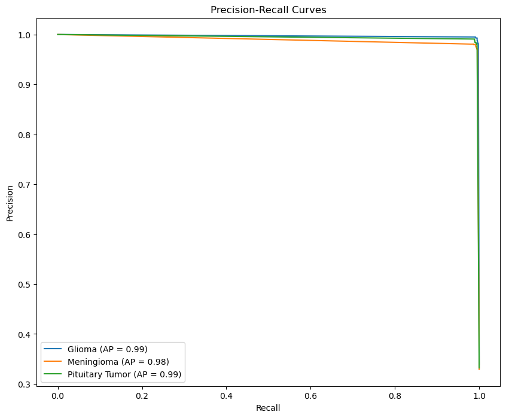

```python
evaluate_model(model, val_ds, translated_class_names)
```

# **Grad-CAM Visualization**

### Explanation:

- **Highlights important regions used for classification**.
- Provides **visual explanations** for model predictions.
- Helps interpretability in medical applications.
- Uses **gradient-based heatmaps** to show activated areas in MRI scans.

```python
import numpy as np
import tensorflow as tf
import matplotlib.pyplot as plt
import cv2

# Extract the base MobileNet model from Sequential
base_model = model.layers[0]  # MobileNet is at index 0 inside Sequential

# Find the last Conv2D layer inside MobileNet
conv_layers = [layer for layer in base_model.layers if isinstance(layer, tf.keras.layers.Conv2D)]
if not conv_layers:
    raise ValueError("No Conv2D layers found in the base MobileNet model.")
last_conv_layer = conv_layers[-1]

# Define Grad-CAM model
grad_model = tf.keras.models.Model(
    inputs=base_model.input,
    outputs=[last_conv_layer.output, base_model.output]
)
```

# **Computing Grad-CAM**

### Explanation:

- Implements **Grad-CAM (Gradient-weighted Class Activation Mapping)**.
- **Highlights important image regions** used by the model for classification.
- Steps:
  1. Extracts **feature maps from the last convolutional layer**.
  2. Computes **gradients of the target class** with respect to feature maps.
  3. Averages gradients and **weights feature maps accordingly**.
  4. Generates **heatmaps** to overlay on original images.

```python
def compute_gradcam(grad_model, img_array, last_conv_layer):
    """Computes Grad-CAM heatmap for an input image."""
    with tf.GradientTape() as tape:
        conv_output, predictions = grad_model(img_array)
        pred_class = tf.argmax(predictions[0]).numpy()  # Extract class index
        loss = tf.gather(predictions, pred_class, axis=-1)  # Fix shape issue

    grads = tape.gradient(loss, conv_output)
    pooled_grads = tf.reduce_mean(grads, axis=(0, 1, 2))

    conv_output = conv_output.numpy()[0]

    # Debugging: Print the shape of the last convolutional output
    print("Conv Output Shape:", conv_output.shape)  # <-- ADD THIS LINE
    heatmap = np.mean(conv_output * pooled_grads.numpy(), axis=-1)

    # Fix: Prevent NaN errors & ensure proper scaling
    eps = 1e-10
    heatmap = np.maximum(heatmap, 0)
    heatmap /= (np.max(heatmap) + eps)  # Normalize safely

    # Fix: Resize heatmap using TensorFlow for better alignment
    heatmap = tf.image.resize(heatmap[..., np.newaxis], (224, 224), method=tf.image.ResizeMethod.BICUBIC).numpy()
    heatmap = np.squeeze(heatmap)  # Remove extra dimension

    return heatmap
```

# **Overlaying Grad-CAM Heatmap**

### Explanation:

- Merges the **Grad-CAM heatmap with the original image**.
- Highlights **critical regions** that influenced the model's decision.
- Uses **color-mapping techniques** to make the visualization clearer.
- Ensures the **overlay is aligned correctly** for proper interpretation.

```python
def overlay_gradcam(image_np, heatmap):
    """Overlays the Grad-CAM heatmap on an image with correct alignment."""
    heatmap = np.uint8(255 * heatmap)  # Convert to color range
    heatmap = cv2.applyColorMap(heatmap, cv2.COLORMAP_JET)

    # Fix: Ensure proper image format before overlaying
    if image_np.shape[-1] == 1:  # Convert grayscale to RGB if needed
        image_np = cv2.cvtColor(image_np, cv2.COLOR_GRAY2RGB)

    # Convert image from RGB to BGR (OpenCV uses BGR)
    image_bgr = cv2.cvtColor(image_np, cv2.COLOR_RGB2BGR)

    # Fix: Use cv2.addWeighted correctly
    overlay = cv2.addWeighted(image_bgr, 0.6, heatmap, 0.4, 0)

    # Convert back to RGB for correct visualization in Matplotlib
    return cv2.cvtColor(overlay, cv2.COLOR_BGR2RGB)
```

# **Displaying Grad-CAM Results for Multiple Samples**

### Explanation:

- Applies **Grad-CAM visualization** to **multiple validation images**.
- Displays a **grid of original images and their Grad-CAM overlays**.
- Helps verify whether the model is **focusing on relevant tumor regions**.
- Uses **Matplotlib** to generate structured plots.

```python
def show_gradcam_samples(dataset, samples_per_class=3, class_names=None):
    """
    Display a 3x3 grid of Grad-CAM visualizations for sample images from each class.

    Args:
        dataset: TensorFlow dataset
        samples_per_class: Number of samples to show per class
        class_names: List of class names (optional)
    """
    samples = {}

    for images, labels in dataset:
        for image, label in zip(images, labels):
            label = int(label)
            if label not in samples:
                samples[label] = []
            if len(samples[label]) < samples_per_class:
                samples[label].append(image)
        if all(len(imgs) >= samples_per_class for imgs in samples.values()):
            break

    fig, axes = plt.subplots(3, 3, figsize=(10, 10))  # 3x3 grid

    for i, (label, images) in enumerate(samples.items()):
        for j, image in enumerate(images):
            img_array = np.expand_dims(image, axis=0)

            # Convert image back to 0-255 range before Grad-CAM
            image_np = np.array(image * 255, dtype=np.uint8)

            # Compute Grad-CAM heatmap
            heatmap = compute_gradcam(grad_model, img_array, last_conv_layer)

            # Convert image to numpy format
            image_np = np.array(image * 255, dtype=np.uint8)

            # Generate Grad-CAM overlay
            overlay = overlay_gradcam(image_np, heatmap)

            ax = axes[i, j]
            ax.imshow(overlay)
            ax.axis('off')

            if j == 0:
                title = f"Class {label}"
                if class_names and label < len(class_names):
                    title = class_names[label]
                ax.set_title(title, pad=10)

    plt.tight_layout()
    plt.show()
```

```
Conv Output Shape: (7, 7, 1024)
Conv Output Shape: (7, 7, 1024)
Conv Output Shape: (7, 7, 1024)
Conv Output Shape: (7, 7, 1024)
Conv Output Shape: (7, 7, 1024)
Conv Output Shape: (7, 7, 1024)
Conv Output Shape: (7, 7, 1024)
Conv Output Shape: (7, 7, 1024)
Conv Output Shape: (7, 7, 1024)
```

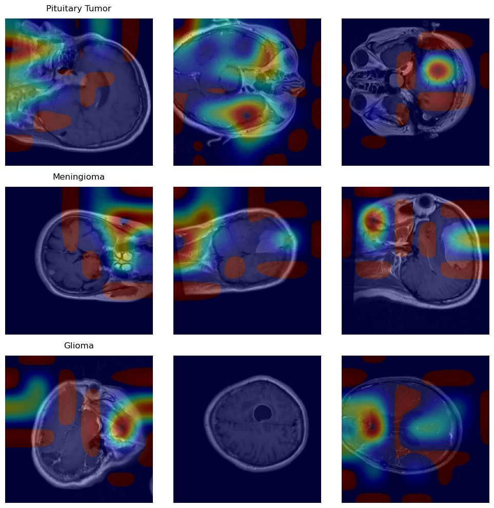

```python
# Execute Grad-CAM visualization for 9 images (3 per class)
show_gradcam_samples(val_ds, samples_per_class=3, class_names=translated_class_names)
```

```python
# Only delete the directory after evaluation is complete
import shutil
try:
    shutil.rmtree(subset_dir)
except Exception as e:
    print(f"Warning: Could not clean up temporary directory: {e}")
```

```python
# Save model
model.save(model_store_dir)
```